# PISA

FRANCISCO DEL VAL

10/11/2020

#### CARGA LIBRERIASA

```r
library(tidyverse)
library(knitr)
library(gam) #GAM
library(rsample) #Para el train/test
library(bestglm) # Cross Validation
library(glmnet) # Regularization
library(leaps) # Model selection
library(caret) # Cross Validation
library(broom) # modelos en df
library(flextable) # Tablas formateadas
library(reshape2)
library(janitor) # Limpieza de nombres
library(dplyr)
library(magrittr) # Pipe operators %<>%
library(imputeTS) # na_mean()
```

```r
library(skimr) # Summary bonito
library(PerformanceAnalytics) #  chart.correlation
# CARGa Y VISUALIZACION DE LA BASE DE DATOS
pisa = read.csv("../data/pisasci2006.csv")
head(pisa)
```

```
##      Country Overall Issues Explain Evidence Interest Support Income Health
## 1    Albania      NA     NA      NA       NA       NA      NA  0.599  0.886
## 2  Argentina     391    395     386      385      567     506  0.678  0.868
## 3  Australia     527    535     520      531      465     487  0.826  0.965
## 4    Austria     511    505     516      505      507     515  0.835  0.944
## 5 Azerbaijan     382    353     412      344      612     542  0.566  0.780
## 6    Belgium     510    515     503      516      503     492  0.831  0.935
##     Edu   HDI
## 1 0.716 0.724
## 2 0.786 0.773
## 3 0.978 0.920
## 4 0.824 0.866
## 5    NA    NA
## 6 0.868 0.877
```

# SUMMARIZE

```r
skim(pisa)
```

Data summary

| Name | pisa |
| --- | --- |
| Number of rows | 65 |
| Number of columns | 11 |
| _______________________ |  |
| Column type frequency: |  |
| character | 1 |
| numeric | 10 |
| ________________________ |  |
| Group variables | None |

**Variable type: character**

| skim_variable | n_missing | complete_rate | min | max | empty | n_unique | whitespace |
| --- | --- | --- | --- | --- | --- | --- | --- |
| Country | 0 | 1 | 4 | 24 | 0 | 65 | 0 |

**Variable type: numeric**

| skim_variable | n_missing | complete_rate | mean | sd | p0 | p25 | p50 | p75 | p100 | hist |
| --- | --- | --- | --- | --- | --- | --- | --- | --- | --- | --- |
| Overall | 8 | 0.88 | 473.14 | 54.58 | 322.00 | 428.00 | 489.00 | 513.00 | 563.00 | ▁▃▂▇▅ |
| Issues | 8 | 0.88 | 469.91 | 53.93 | 321.00 | 427.00 | 489.00 | 514.00 | 555.00 | ▁▃▂▇▆ |
| Explain | 8 | 0.88 | 475.02 | 54.02 | 334.00 | 432.00 | 490.00 | 517.00 | 566.00 | ▁▃▂▇▃ |
| Evidence | 8 | 0.88 | 469.81 | 61.74 | 288.00 | 423.00 | 489.00 | 515.00 | 567.00 | ▁▂▃▇▆ |
| Interest | 8 | 0.88 | 528.16 | 49.84 | 448.00 | 501.00 | 522.00 | 565.00 | 644.00 | ▆▇▅▃▂ |
| Support | 8 | 0.88 | 512.18 | 26.08 | 447.00 | 494.00 | 512.00 | 529.00 | 569.00 | ▂▅▇▆▂ |
| Income | 4 | 0.94 | 0.74 | 0.11 | 0.41 | 0.66 | 0.76 | 0.83 | 0.94 | ▁▃▇▇▆ |
| Health | 4 | 0.94 | 0.89 | 0.07 | 0.72 | 0.84 | 0.89 | 0.94 | 0.99 | ▂▂▇▆▇ |
| Edu | 6 | 0.91 | 0.80 | 0.11 | 0.54 | 0.72 | 0.81 | 0.88 | 0.99 | ▂▅▆▇▅ |
| HDI | 6 | 0.91 | 0.81 | 0.09 | 0.58 | 0.75 | 0.82 | 0.88 | 0.94 | ▁▃▇▇▇ |

#### LIMPIEZA DE DATOS

Las variables clave son las siguientes:

- Overall Science Score (average score for 15 year olds)
- Interest in science
- Support for scientific inquiry
- Income Index
- Health Index
- Education Index
- Human Development Index (composed of the Income index, Health Index, and Education Index

```r
# limpieza de los nombres con la funcion clean_names(). por defecto es en minuscula y lo compuestos separados con _
pisa %<>% clean_names()
```

```r
# comprobamos que se han cambiado los nombres.
colnames(pisa)
```

```
##  [1] "country"  "overall"  "issues"   "explain"  "evidence" "interest"
##  [7] "support"  "income"   "health"   "edu"      "hdi"
```

Dupliados:

```r
# Eliminamos los duplicados si existen
# utilizo una funcion que me guarde todos los paises que sean distintos
pisa %<>% distinct(country, .keep_all = T)
```

Nuestro dataset presenta bastantes NaN. Hacemos la media para no perder informacion

```r
# contamos los nulos
# ordeno que me diga los nulos que aparecen en cada una de las columnas
summarise_all(pisa, funs(sum(is.na(.))))
```

```
##   country overall issues explain evidence interest support income health edu
## 1       0       8      8       8        8        8       8      4      4   6
##   hdi
## 1   6
```

```r
# hago la media de los na de pisa
pisa <- na_mean(pisa)
```

```r
# vemos la base de datos limpias
view(pisa)
attach(pisa)
```

# Variable excluida

```r
var_ex <- c('country')
```

#### CORRELACIONES

```
## Note: Using an external vector in selections is ambiguous.
## i Use `all_of(var_ex)` instead of `var_ex` to silence this message.
## i See <https://tidyselect.r-lib.org/reference/faq-external-vector.html>.
```

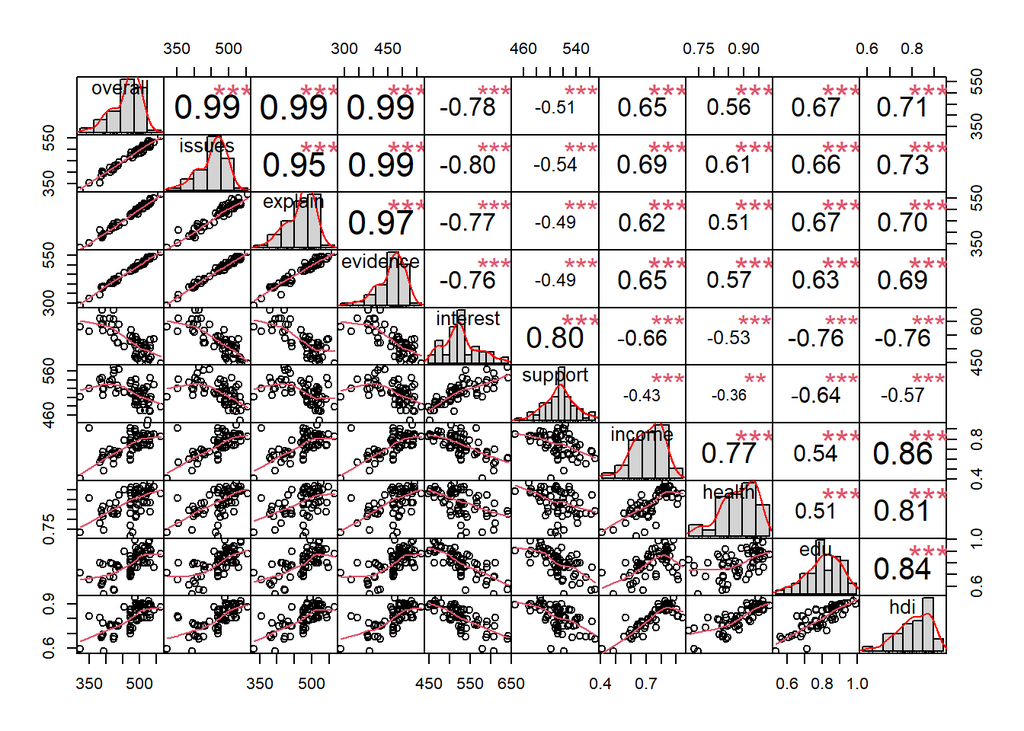

```r
# correlaciones
chart.Correlation(pisa %>%
               select_at(vars(-var_ex)),
               histogram = TRUE, pch = 19 )
```

Las estrellas en rojo lo que indica es que si es distinta de 0. Las lineas rectas determinan que no hay relacion entre ellas

existen relaciones fuerte como hdi (Índice de Desarrollo Humano) con la educación, la salud o la renta.

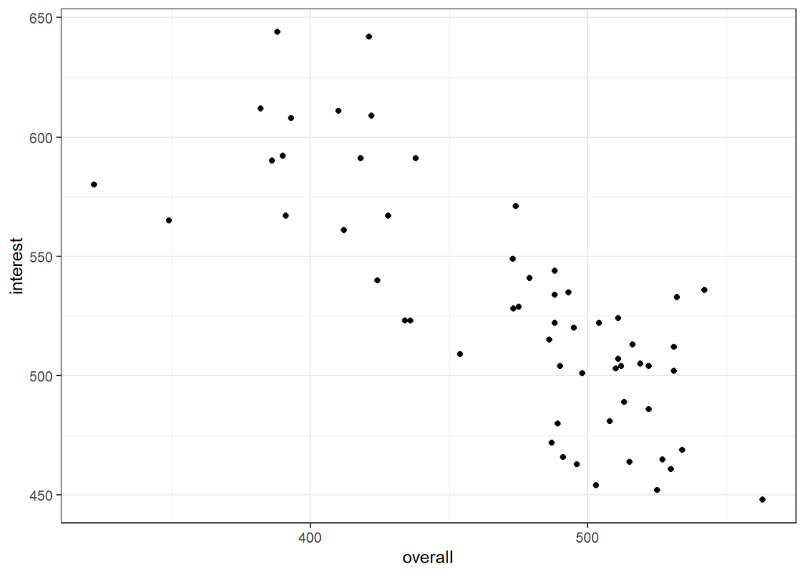

```r
# Grafico interest
baseplot1 <- ggplot(data = pisa, mapping = aes(x = overall, y = interest)) +
  layer(geom = "point",stat = "identity",position = "identity") +
  theme_bw() + theme(legend.key = element_blank())
baseplot1
```

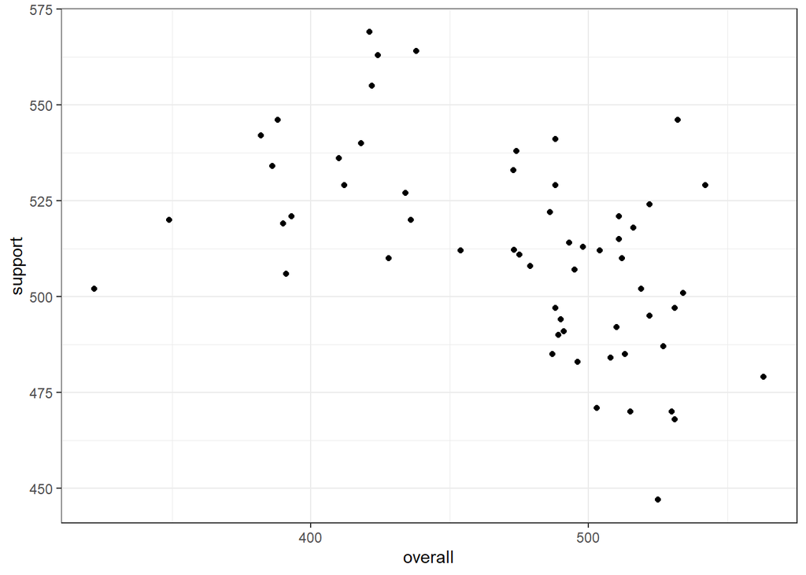

```r
# Grafico Support
baseplot1 <- ggplot(data = pisa, mapping = aes(x = overall, y = support)) +
  layer(geom = "point",stat = "identity",position = "identity") +
  theme_bw() + theme(legend.key = element_blank())
baseplot1
```

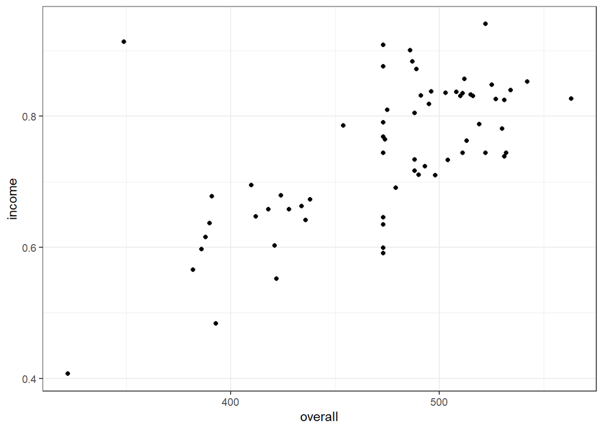

```r
# Grafico income
baseplot1 <- ggplot(data = pisa, mapping = aes(x = overall, y = income)) +
  layer(geom = "point",stat = "identity",position = "identity") +
  theme_bw() + theme(legend.key = element_blank())
baseplot1
```

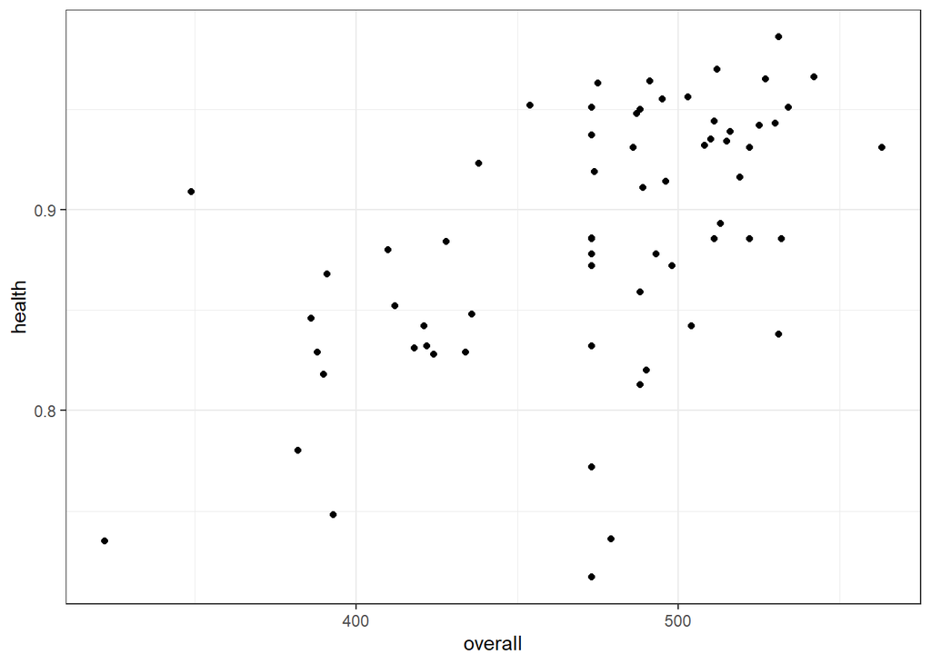

```r
# Grafico health
baseplot1 <- ggplot(data = pisa, mapping = aes(x = overall, y = health)) +
  layer(geom = "point",stat = "identity",position = "identity") +
  theme_bw() + theme(legend.key = element_blank())
baseplot1
```

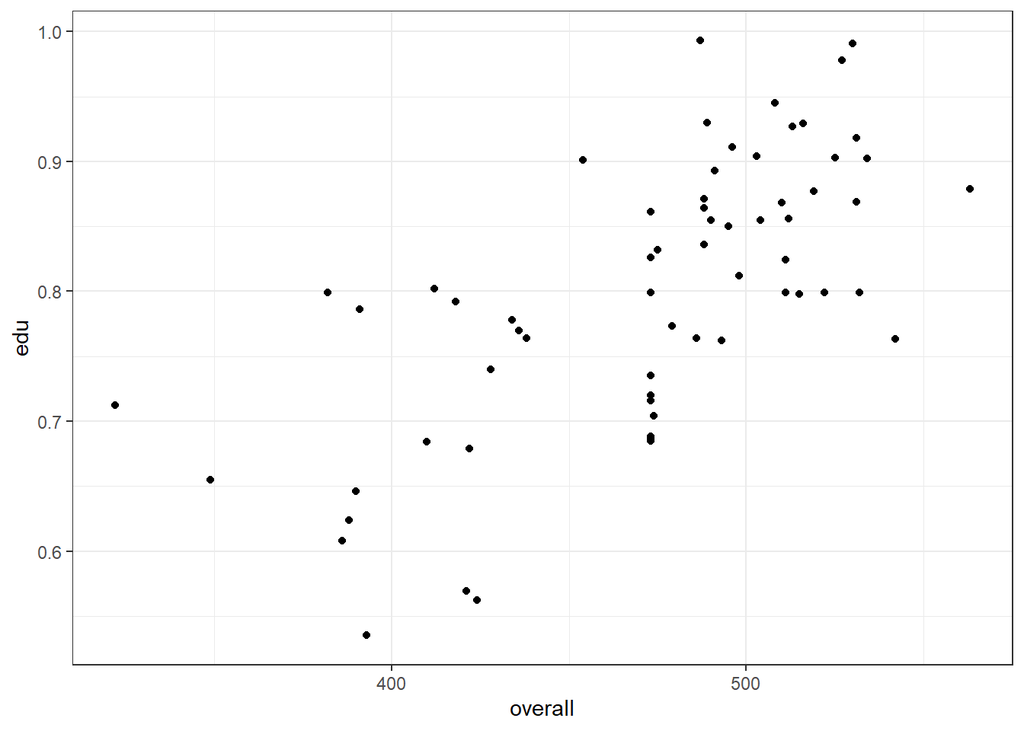

```r
# Grafico edu
baseplot1 <- ggplot(data = pisa, mapping = aes(x = overall, y = edu)) +
  layer(geom = "point",stat = "identity",position = "identity") +
  theme_bw() + theme(legend.key = element_blank())
baseplot1
```

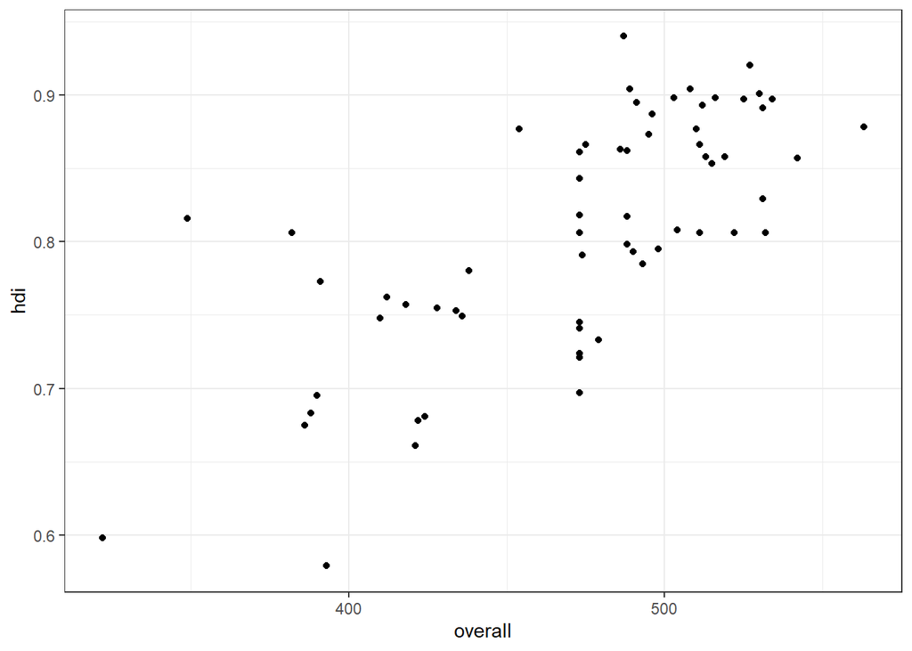

```r
# Grafico hdi
baseplot1 <- ggplot(data = pisa, mapping = aes(x = overall, y = hdi)) +
  layer(geom = "point",stat = "identity",position = "identity") +
  theme_bw() + theme(legend.key = element_blank())
baseplot1
```

### GRADOS DE LIBERTAD

```r
# smooth spline con cv:

# Saco los grados de libertad de cada variable junto con el CV.
# Solo los calculo para las variables que no son categoricas ni dumbies.

fit_interest <- smooth.spline(x = interest, y = overall, cv = TRUE)
fit_support <- smooth.spline(x = support, y = overall, cv = TRUE)
fit_income <- smooth.spline(x = income, y = overall, cv = TRUE)
fit_health <- smooth.spline(x = health, y = overall, cv = TRUE)
fit_edu <- smooth.spline(x = edu, y = overall, cv = TRUE)
fit_hdi <- smooth.spline(x = hdi, y = overall, cv = TRUE)
fit_interest$df
```

```
## [1] 4.750171
```

```r
fit_support$df
```

```
## [1] 2.001243
```

```r
fit_income$df
```

```
## [1] 4.244952
```

```r
fit_health$df
```

```
## [1] 2.002844
```

```r
fit_edu$df
```

```
## [1] 2.002385
```

```r
fit_hdi$df
```

```
## [1] 8.603228
```

[figure not shown]

```r
# comparamos la variable interest con 16 grados de libertad




plot(interest, overall, col='black')
criterio_aleatorio <- smooth.spline(interest, overall, df=16)
criterio_smooth <- smooth.spline(interest, overall, cv=TRUE)
lines(criterio_aleatorio, col='green', lwd=2)
lines(criterio_smooth, col='blue', lwd=1)
legend('topright', legend=c('4.750171 DF', '16DF'),
       col=c('green','blue'), lty=1, lwd=2, cex=0.8)
```

La linea verde representa los grados de libertar credos manualemnte la linea azul representa el smooth spline (modelo suavizado)

#### MODELOS ADITIVOS GENERALIZADOS (GAM)

GAM 1

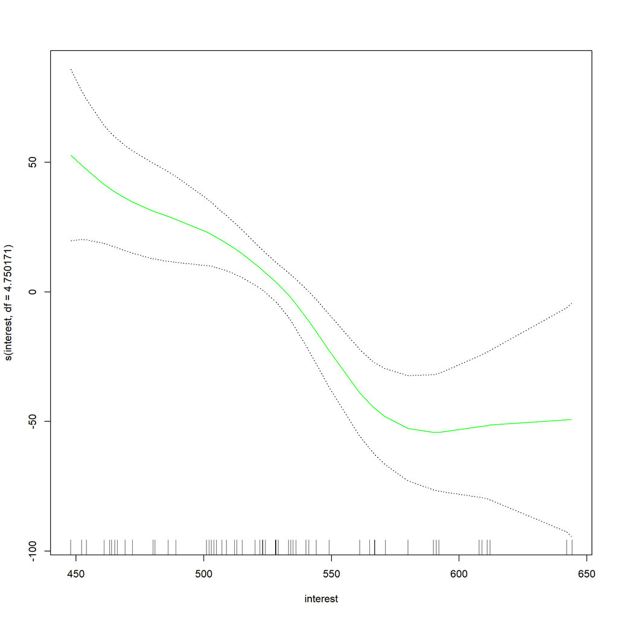

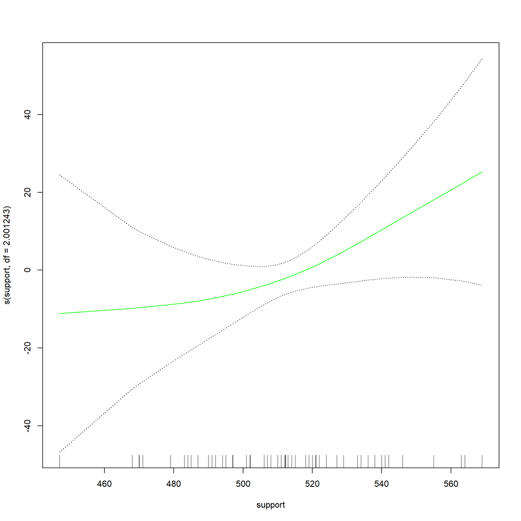

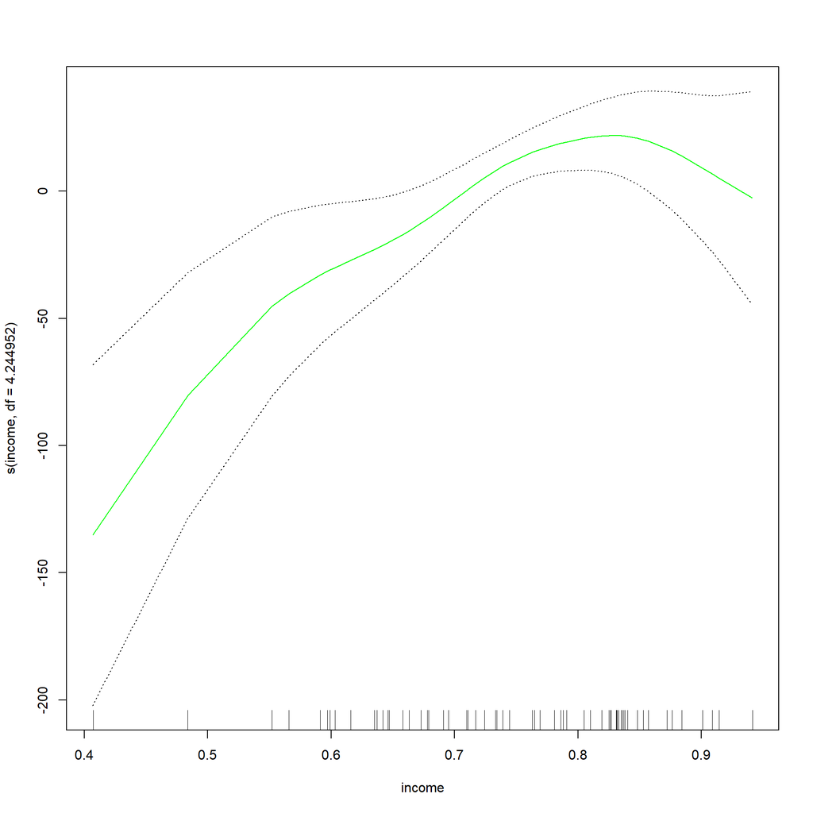

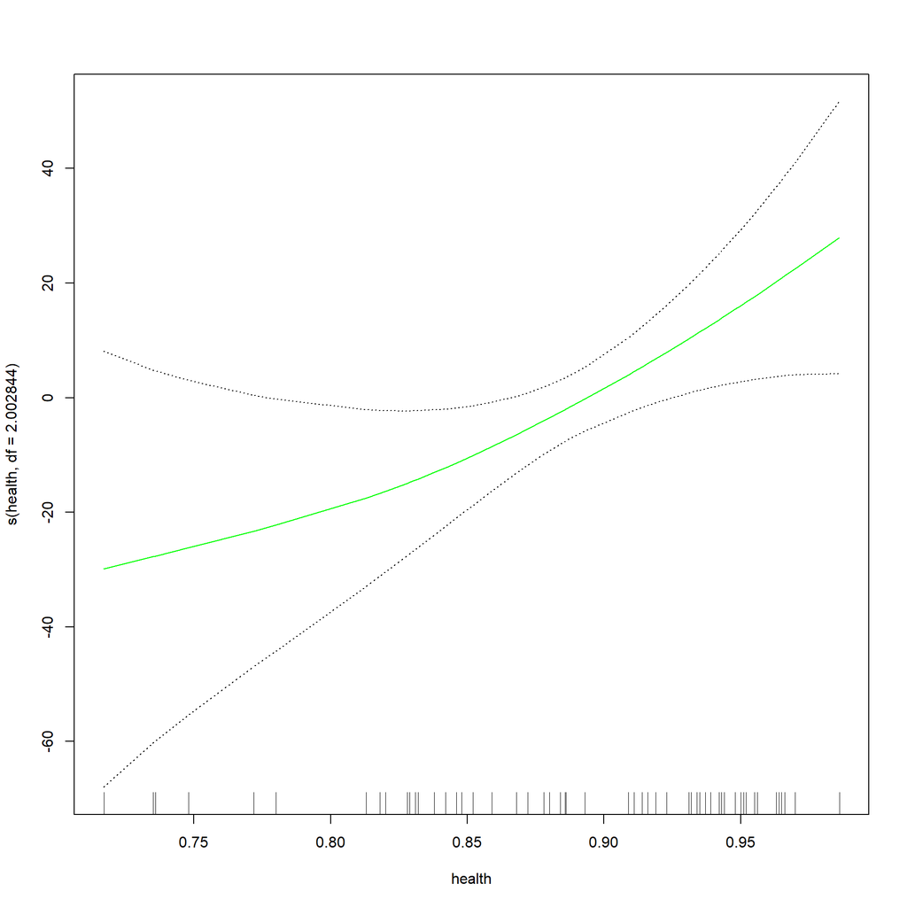

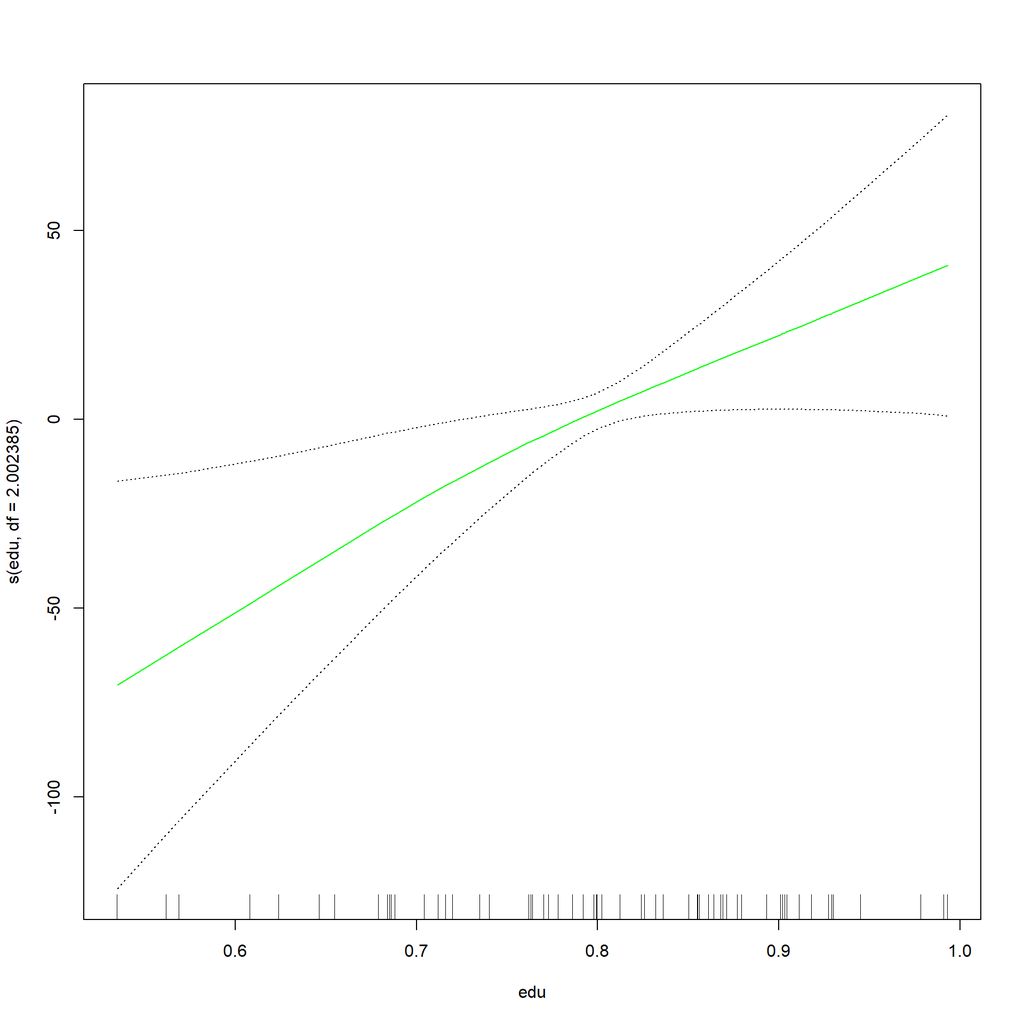

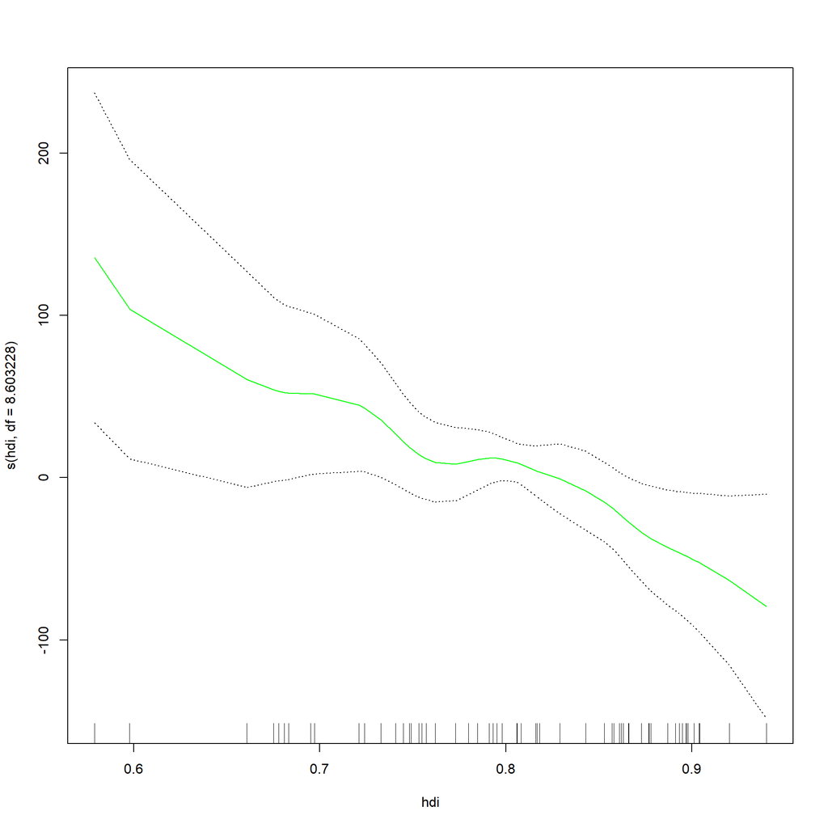

```r
# modelos con GAM:

gam1 <- gam(overall~ s(interest, df=4.750171) + s(support,df=2.001243) + s(income,df=4.244952) + s(health,df=2.002844) + s(edu,df=2.002385) + s(hdi,df=8.603228),
            data = pisa)
plot(gam1, se=TRUE, col = 'green')
```

```r
summary(gam1)
```

```
##
## Call: gam(formula = overall ~ s(interest, df = 4.750171) + s(support,
##     df = 2.001243) + s(income, df = 4.244952) + s(health, df = 2.002844) +
##     s(edu, df = 2.002385) + s(hdi, df = 8.603228), data = pisa)
## Deviance Residuals:
##     Min      1Q  Median      3Q     Max
## -60.474  -8.204   3.146  11.663  51.433
##
## (Dispersion Parameter for gaussian family taken to be 596.1798)
##
##     Null Deviance: 166828.9 on 64 degrees of freedom
## Residual Deviance: 24082.78 on 40.3952 degrees of freedom
## AIC: 620.1379
##
## Number of Local Scoring Iterations: NA
##
## Anova for Parametric Effects
##                                Df Sum Sq Mean Sq  F value   Pr(>F)
## s(interest, df = 4.750171)  1.000  90386   90386 151.6092 2.96e-15 ***
## s(support, df = 2.001243)   1.000   2922    2922   4.9011  0.03255 *
## s(income, df = 4.244952)    1.000   4153    4153   6.9665  0.01174 *
## s(health, df = 2.002844)    1.000    743     743   1.2458  0.27095
## s(edu, df = 2.002385)       1.000    341     341   0.5713  0.45413
## s(hdi, df = 8.603228)       1.000   3326    3326   5.5795  0.02308 *
## Residuals                  40.395  24083     596
## ---
## Signif. codes:  0 '***' 0.001 '**' 0.01 '*' 0.05 '.' 0.1 ' ' 1
##
## Anova for Nonparametric Effects
##                            Npar Df Npar F   Pr(F)
## (Intercept)
## s(interest, df = 4.750171)     3.8 3.3651 0.02010 *
## s(support, df = 2.001243)      1.0 1.6195 0.21046
## s(income, df = 4.244952)       3.2 6.2325 0.00109 **
## s(health, df = 2.002844)       1.0 1.4044 0.24301
## s(edu, df = 2.002385)          1.0 1.7024 0.19939
## s(hdi, df = 8.603228)          7.6 1.2305 0.30759
## ---
## Signif. codes:  0 '***' 0.001 '**' 0.01 '*' 0.05 '.' 0.1 ' ' 1
```

Ahora hago otro modelo pero quitando el smooth spline de las variables suport, health y edu

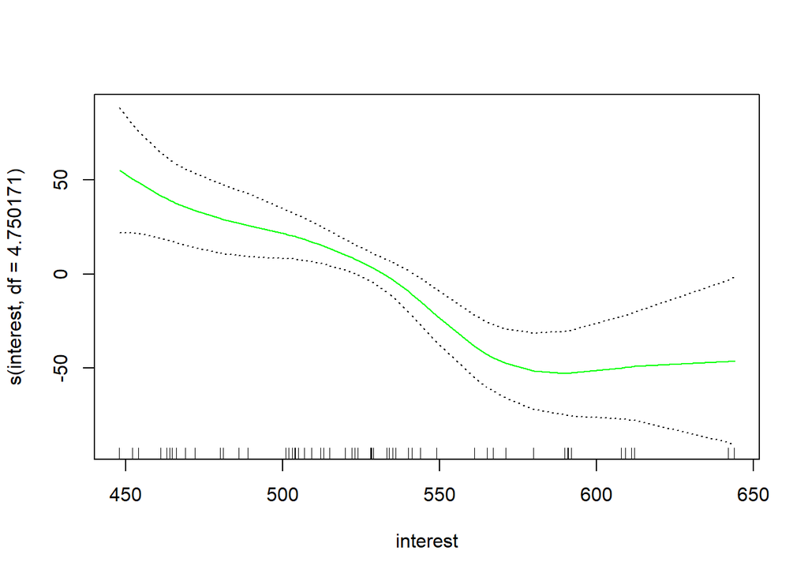

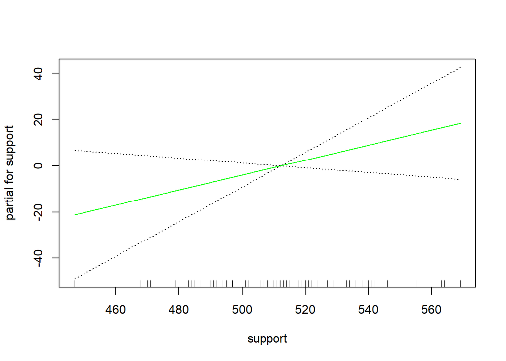

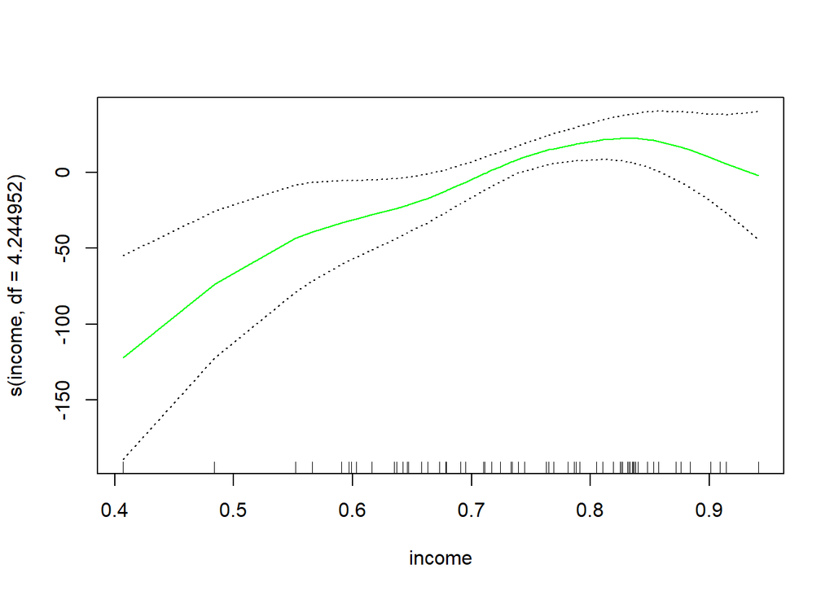

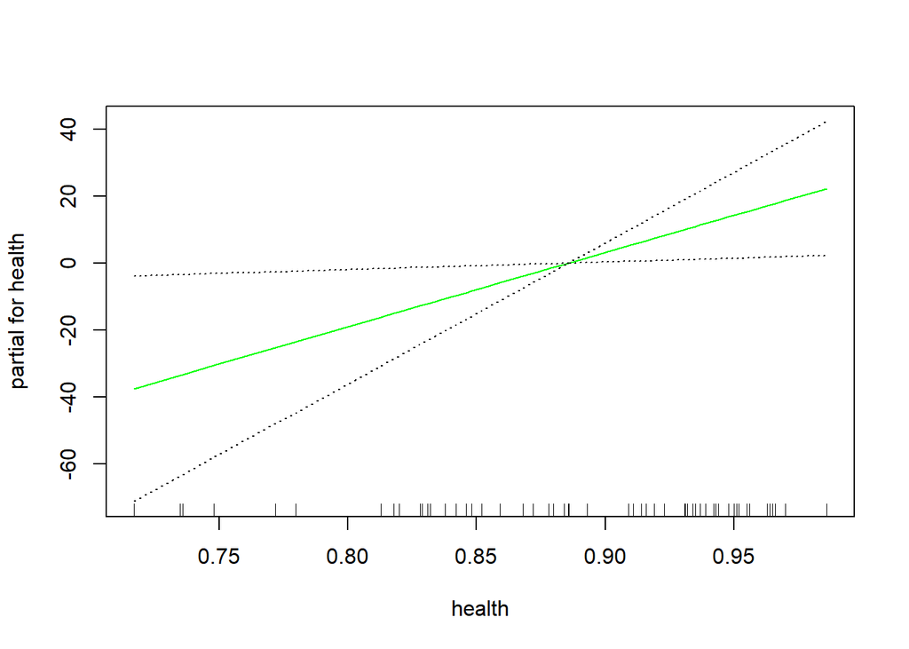

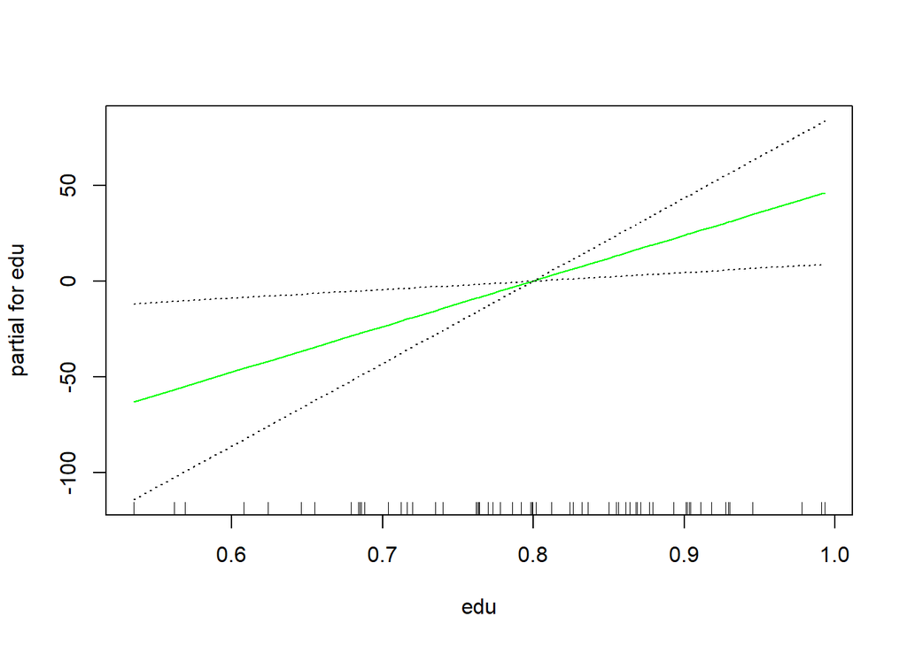

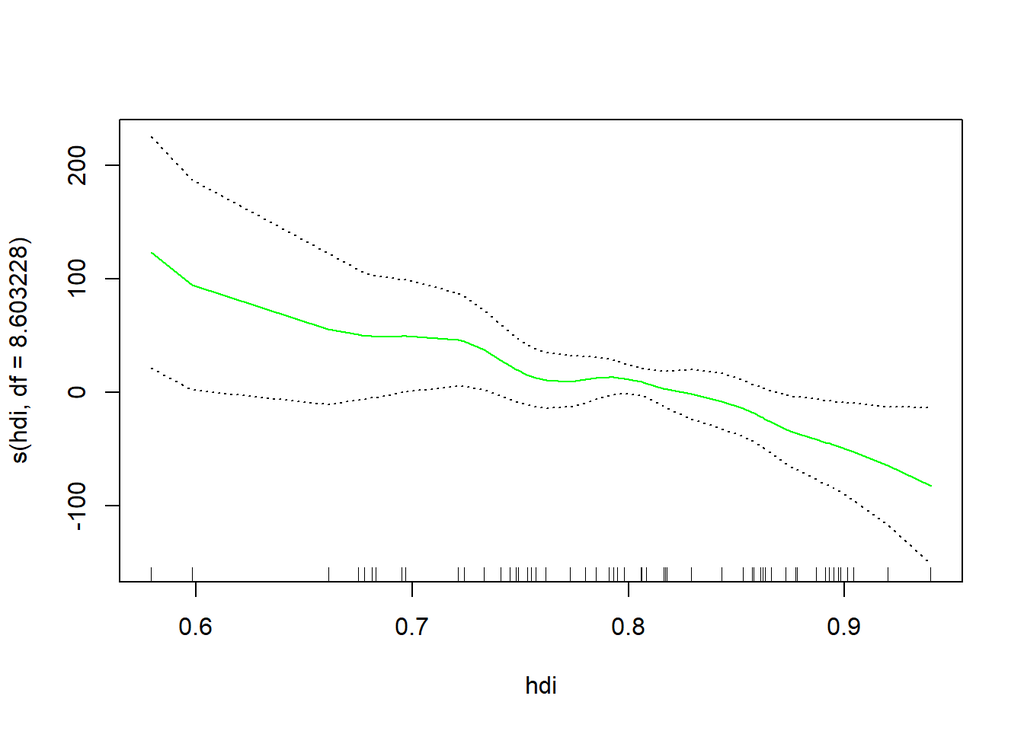

```r
gam2 <- gam(overall ~ s(interest, df=4.750171) + support + s(income, df=4.244952)+ health + edu + s(hdi, df=8.603228),
            data = pisa )
plot(gam2, se=TRUE, col='green')
```

```r
summary(gam2)
```

```
##
## Call: gam(formula = overall ~ s(interest, df = 4.750171) + support +
##     s(income, df = 4.244952) + health + edu + s(hdi, df = 8.603228),
##     data = pisa)
## Deviance Residuals:
##     Min      1Q  Median      3Q     Max
## -64.105  -8.624   3.353  10.801  54.623
##
## (Dispersion Parameter for gaussian family taken to be 598.5364)
##
##     Null Deviance: 166828.9 on 64 degrees of freedom
## Residual Deviance: 25977.54 on 43.4018 degrees of freedom
## AIC: 619.0475
##
## Number of Local Scoring Iterations: NA
##
## Anova for Parametric Effects
##                                Df Sum Sq Mean Sq  F value    Pr(>F)
## s(interest, df = 4.750171)  1.000  91111   91111 152.2224 8.748e-16 ***
## support                     1.000   2862    2862   4.7817  0.034201 *
## s(income, df = 4.244952)    1.000   4395    4395   7.3426  0.009603 **
## health                      1.000    826     826   1.3798  0.246545
## edu                         1.000    570     570   0.9529  0.334383
## s(hdi, df = 8.603228)       1.000   3092    3092   5.1662  0.028038 *
## Residuals                  43.402  25978     599
## ---
## Signif. codes:  0 '***' 0.001 '**' 0.01 '*' 0.05 '.' 0.1 ' ' 1
##
## Anova for Nonparametric Effects
##                            Npar Df Npar F    Pr(F)
## (Intercept)
## s(interest, df = 4.750171)     3.8 3.4750 0.016844 *
## support
## s(income, df = 4.244952)       3.2 5.1134 0.003309 **
## health
## edu
## s(hdi, df = 8.603228)          7.6 1.2566 0.292136
## ---
## Signif. codes:  0 '***' 0.001 '**' 0.01 '*' 0.05 '.' 0.1 ' ' 1
```

Ahora hago otro modelo pero quitando el smooth spline de hdi

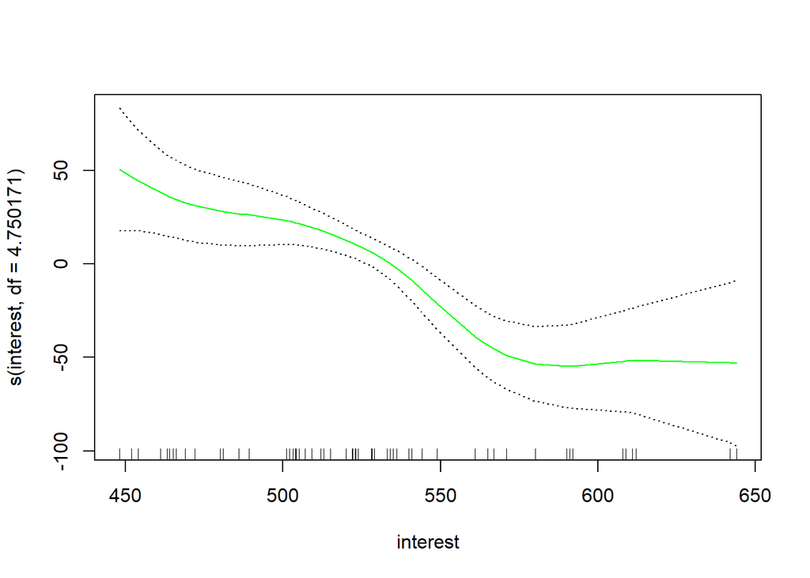

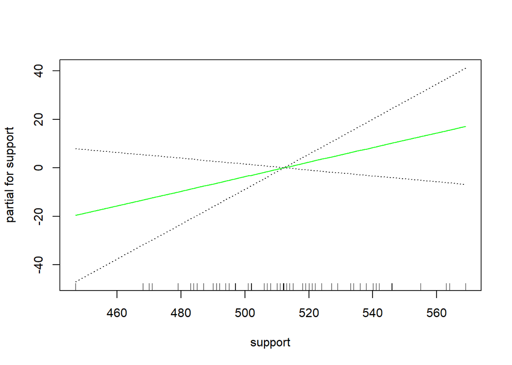

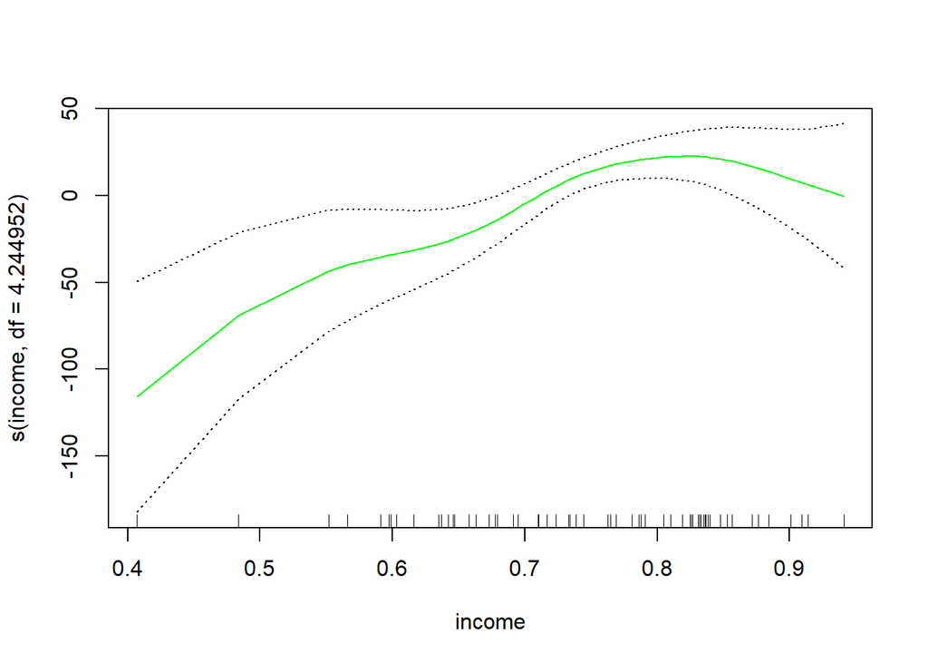

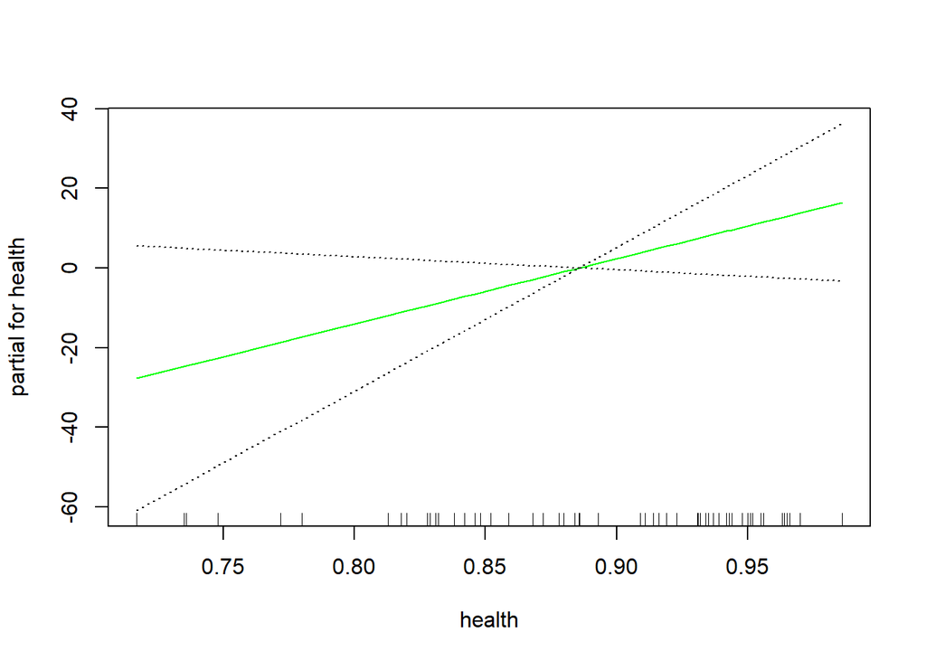

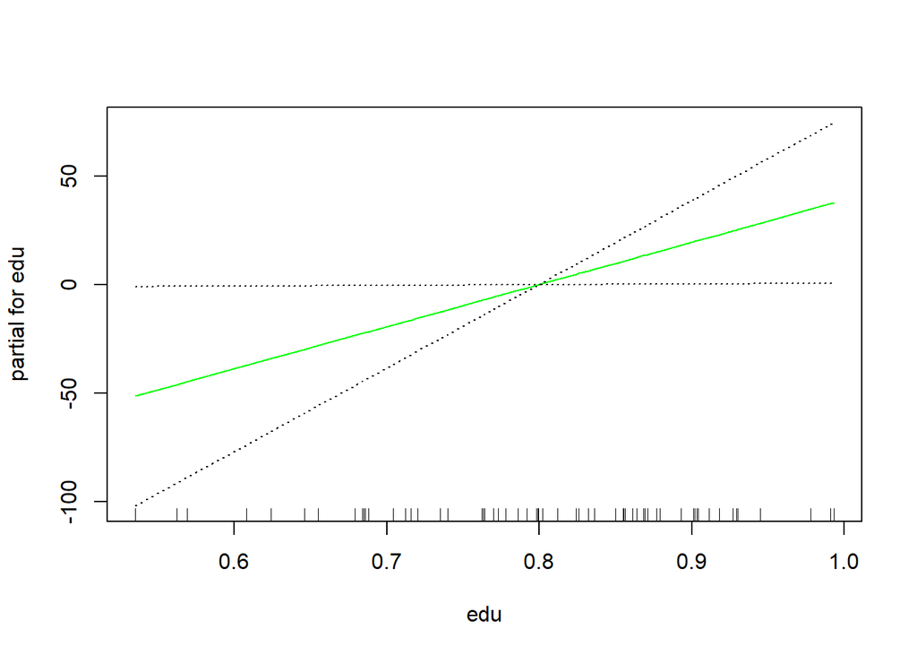

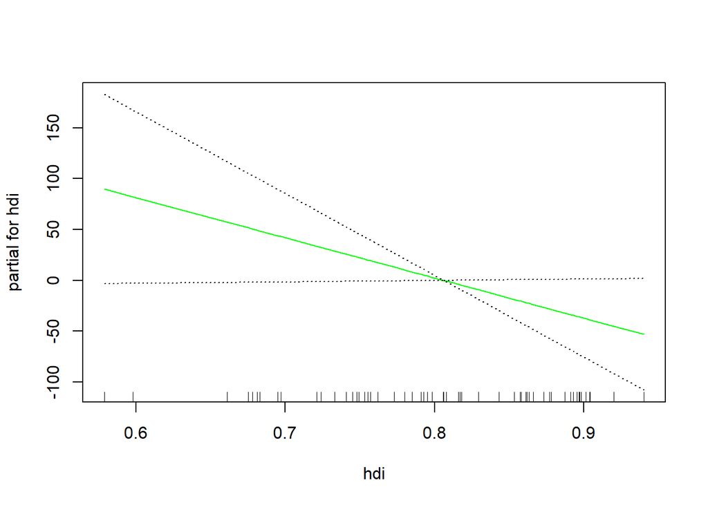

```r
gam3 <- gam(overall ~ s(interest, df=4.750171) + support + s(income, df=4.244952)+ health + edu + hdi,
            data = pisa )
plot(gam3, se=TRUE, col='green')
```

```r
summary(gam3)
```

```
##
## Call: gam(formula = overall ~ s(interest, df = 4.750171) + support +
##     s(income, df = 4.244952) + health + edu + hdi, data = pisa)
## Deviance Residuals:
##     Min      1Q  Median      3Q     Max
## -61.715 -12.685   3.772  12.762  59.615
##
## (Dispersion Parameter for gaussian family taken to be 584.3127)
##
##     Null Deviance: 166828.9 on 64 degrees of freedom
## Residual Deviance: 29802.77 on 51.0048 degrees of freedom
## AIC: 612.7704
##
## Number of Local Scoring Iterations: NA
##
## Anova for Parametric Effects
##                                Df Sum Sq Mean Sq  F value    Pr(>F)
## s(interest, df = 4.750171)  1.000  91508   91508 156.6072 < 2.2e-16 ***
## support                     1.000   2756    2756   4.7165  0.034549 *
## s(income, df = 4.244952)    1.000   5338    5338   9.1359  0.003915 **
## health                      1.000    263     263   0.4501  0.505296
## edu                         1.000    288     288   0.4928  0.485892
## hdi                         1.000   2183    2183   3.7368  0.058786 .
## Residuals                  51.005  29803     584
## ---
## Signif. codes:  0 '***' 0.001 '**' 0.01 '*' 0.05 '.' 0.1 ' ' 1
##
## Anova for Nonparametric Effects
##                            Npar Df Npar F    Pr(F)
## (Intercept)
## s(interest, df = 4.750171)     3.8 4.0742 0.007085 **
## support
## s(income, df = 4.244952)       3.2 5.8854 0.001211 **
## health
## edu
## hdi
## ---
## Signif. codes:  0 '***' 0.001 '**' 0.01 '*' 0.05 '.' 0.1 ' ' 1
```

como se puede observar mejora el AIC

Por ultimo, analizamos la varianza para ver que modelo nos quedamo

# Análisis de varianza

```r
anova(gam1, gam2, gam3)
```

```
## Analysis of Deviance Table
##
## Model 1: overall ~ s(interest, df = 4.750171) + s(support, df = 2.001243) +
##     s(income, df = 4.244952) + s(health, df = 2.002844) + s(edu,
##     df = 2.002385) + s(hdi, df = 8.603228)
## Model 2: overall ~ s(interest, df = 4.750171) + support + s(income, df = 4.244952) +
##     health + edu + s(hdi, df = 8.603228)
## Model 3: overall ~ s(interest, df = 4.750171) + support + s(income, df = 4.244952) +
##     health + edu + hdi
##   Resid. Df Resid. Dev      Df Deviance Pr(>Chi)
## 1    40.395      24083
## 2    43.402      25978 -3.0066  -1894.8   0.3661
## 3    51.005      29803 -7.6031  -3825.2   0.5587
```

Al considerarse un muestreo tan pequeno, no consideramos oportuno realizar una division de la muestra para el entrenamiento y e test